# Predicting Health Charges

#### Practicum 1, Summer 2020

### Feature Engineering

```python
import numpy as np
import pandas as pd
import seaborn as sns
import phik
from phik import resources, report

from sklearn.preprocessing import Normalizer
```

```python
df = pd.read_csv(r"E:\Regis\Practicum_1\df_cleaned.csv") # Change the file path to match user's local directory
df_profile = df
```

```python
df.info()
```

```
<class 'pandas.core.frame.DataFrame'>
RangeIndex: 1337 entries, 0 to 1336
Data columns (total 8 columns):
 #   Column      Non-Null Count  Dtype
---  ------      --------------  -----
 0   Unnamed: 0  1337 non-null   int64
 1   age         1337 non-null   int64
 2   sex         1337 non-null   object
 3   bmi         1337 non-null   float64
 4   children    1337 non-null   int64
 5   smoker      1337 non-null   object
 6   region      1337 non-null   object
 7   charges     1337 non-null   float64
dtypes: float64(2), int64(3), object(3)
memory usage: 83.7+ KB
```

#### Drop index column.

```python
df=df.drop('Unnamed: 0', axis=1)
df.info()
```

```
<class 'pandas.core.frame.DataFrame'>
RangeIndex: 1337 entries, 0 to 1336
Data columns (total 7 columns):
 #   Column    Non-Null Count  Dtype
---  ------    --------------  -----
 0   age       1337 non-null   int64
 1   sex       1337 non-null   object
 2   bmi       1337 non-null   float64
 3   children  1337 non-null   int64
 4   smoker    1337 non-null   object
 5   region    1337 non-null   object
 6   charges   1337 non-null   float64
dtypes: float64(2), int64(2), object(3)
memory usage: 73.2+ KB
```

#### Copy dataframe

```python
df_2 = df.copy()
```

```python
df_2.info()
```

```
<class 'pandas.core.frame.DataFrame'>
RangeIndex: 1337 entries, 0 to 1336
Data columns (total 7 columns):
 #   Column    Non-Null Count  Dtype
---  ------    --------------  -----
 0   age       1337 non-null   int64
 1   sex       1337 non-null   object
 2   bmi       1337 non-null   float64
 3   children  1337 non-null   int64
 4   smoker    1337 non-null   object
 5   region    1337 non-null   object
 6   charges   1337 non-null   float64
dtypes: float64(2), int64(2), object(3)
memory usage: 73.2+ KB
```

### ϕk correlation matrix

Phi K tutorial: https://nbviewer.ipython.org/github/kaveio/phik/blob/master/python/phik/notebooks/phik_tutorial_basic.ipynb#Load-data  
Calculate the Phi K corrlation matrix.

```python
df.phik_matrix()
```

```
interval_cols not set, guessing: ['age', 'bmi', 'children', 'charges']
```

| var2 var1 | age | bmi | charges | children | region | sex | smoker |
| --- | --- | --- | --- | --- | --- | --- | --- |
| age | 1.000000 | 0.164207 | 0.728530 | 0.316453 | 0.000000 | 0.000000 | 0.055922 |
| bmi | 0.164207 | 1.000000 | 0.377180 | 0.086886 | 0.269618 | 0.000000 | 0.000000 |
| charges | 0.728530 | 0.377180 | 1.000000 | 0.031167 | 0.107869 | 0.081889 | 0.962912 |
| children | 0.316453 | 0.086886 | 0.031167 | 1.000000 | 0.000000 | 0.000000 | 0.052134 |
| region | 0.000000 | 0.269618 | 0.107869 | 0.000000 | 1.000000 | 0.000000 | 0.085519 |
| sex | 0.000000 | 0.000000 | 0.081889 | 0.000000 | 0.000000 | 1.000000 | 0.109088 |
| smoker | 0.055922 | 0.000000 | 0.962912 | 0.052134 | 0.085519 | 0.109088 | 1.000000 |

Checking the correlation matrix it appears that the target, 'charges', is highly correlated with 'smoker' and 'age'.  
It is minimally correlated with 'children' and 'sex'. I will remove them due to the poor correlation. Also, 'children' is positively correlated with 'age' which may cause auto-correlation issues.  
Likewise 'sex' is slightly correlated with 'smoker'. Again, the feature less correlated with the target will be removed to prevent auto-correlation issues.  
Furthermore, 'region', correlates with 'bmi' which is correlated with the target. Consequently, 'region' will be removed.

#### Remove 'region', 'sex', and 'children' features

```python
df.drop(['sex', 'children', 'region'], inplace=True, axis=1)
df.info()
```

```
<class 'pandas.core.frame.DataFrame'>
RangeIndex: 1337 entries, 0 to 1336
Data columns (total 4 columns):
 #   Column   Non-Null Count  Dtype
---  ------   --------------  -----
 0   age      1337 non-null   int64
 1   bmi      1337 non-null   float64
 2   smoker   1337 non-null   object
 3   charges  1337 non-null   float64
dtypes: float64(2), int64(1), object(1)
memory usage: 41.9+ KB
```

This leaves the target feature plus three others: 'age', 'bmi' and 'smoker'.  
The 'smoker' feature is categorical with levels of 'yes' and 'no'. Categorical features will cause problems with the linear regression model and will need to be dealt with.  
The pandas library contains the 'get_dummies' method which will be used to encode the 'smoker' feature.

#### Encode categorical feature

The dataframe is passed as the data parameter which allows the method to determine which features to encode. The 'prefix' parameter is used to assign a value to the resulting columns for ease of readability. The original 'smoker' feature will be dropped and two new encoded features added. The prefix 'smoker' will be added to the new columns.

```python
#encoded_df = pd.get_dummies(df, prefix=['smoker'])

# encode df_2
#df_2 = pd.get_dummies(df_2, prefix=['sex','smoker', 'region'])
df_2 = pd.get_dummies(df_2)
```

```python
encoded_df.info()
```

```
<class 'pandas.core.frame.DataFrame'>
RangeIndex: 1337 entries, 0 to 1336
Data columns (total 5 columns):
 #   Column      Non-Null Count  Dtype
---  ------      --------------  -----
 0   age         1337 non-null   int64
 1   bmi         1337 non-null   float64
 2   charges     1337 non-null   float64
 3   smoker_no   1337 non-null   uint8
 4   smoker_yes  1337 non-null   uint8
dtypes: float64(2), int64(1), uint8(2)
memory usage: 34.1 KB
```

```python
df_2.info()
```

```
<class 'pandas.core.frame.DataFrame'>
RangeIndex: 1337 entries, 0 to 1336
Data columns (total 12 columns):
 #   Column            Non-Null Count  Dtype
---  ------            --------------  -----
 0   age               1337 non-null   int64
 1   bmi               1337 non-null   float64
 2   children          1337 non-null   int64
 3   charges           1337 non-null   float64
 4   sex_female        1337 non-null   uint8
 5   sex_male          1337 non-null   uint8
 6   smoker_no         1337 non-null   uint8
 7   smoker_yes        1337 non-null   uint8
 8   region_northeast  1337 non-null   uint8
 9   region_northwest  1337 non-null   uint8
 10  region_southeast  1337 non-null   uint8
 11  region_southwest  1337 non-null   uint8
dtypes: float64(2), int64(2), uint8(8)
memory usage: 52.4 KB
```

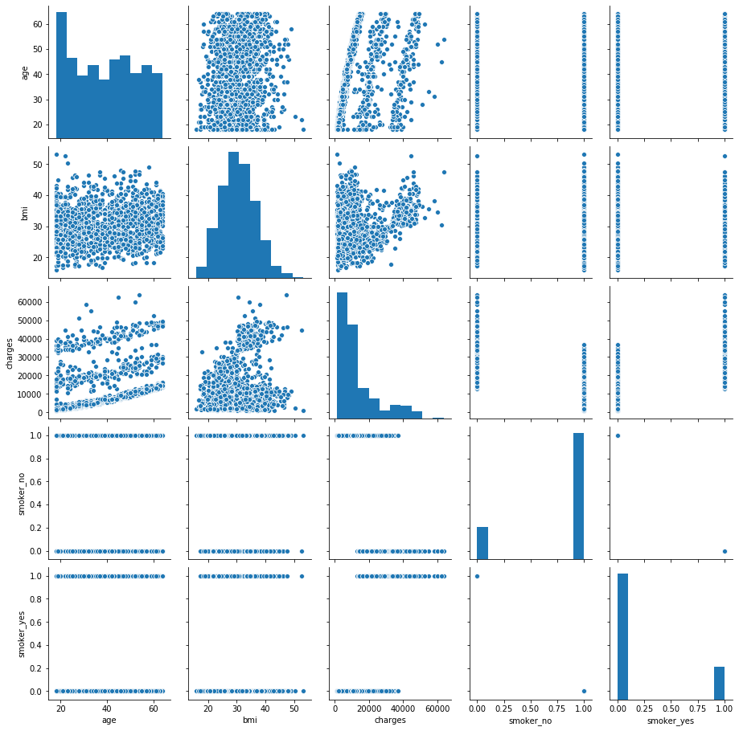

```python
sns.pairplot(encoded_df)
```

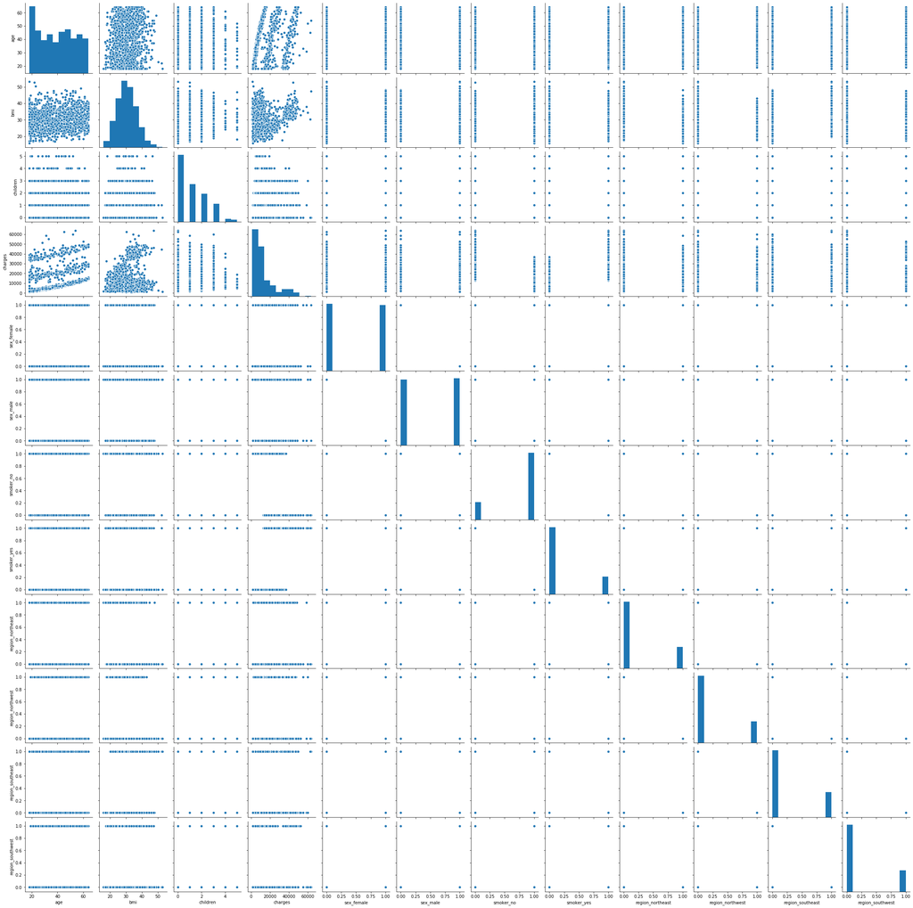

```python
sns.pairplot(df_2)
```

#### Save cleaned data frame

```python
# encoded_df.to_csv(r"E:\Regis\Practicum_1\df_encoded.csv", index=False)
df_2.to_csv(r"E:\Regis\Practicum_1\df_2_all_features.csv", index=False)
```

#### Create additional datframe without 'bmi'

```python
enc_noBmi_df = encoded_df.drop('bmi', axis=1)
```

```python
enc_noBmi_df.to_csv(r"E:\Regis\Practicum_1\df_enc_nobmi.csv", index=False)
```